# Time Series Final Project - Forecasting Hourly Crime at the Neighborhood Level in Chicago

Ian Vogt

2023-05-19

I. DATA PROCESSING

```r
# Load in the data
crimes <- read_csv('crimes.csv')
# Convert the 'Date' column from string to datetime format
crimes$Datetime <- as.POSIXct(crimes$Date, format = '%m/%d/%Y %I:%M:%S %p')

# Order the df by Datetime
crimes <- crimes[order(crimes$Datetime),]
```

```r
# Create separate columns for date and time
crimes$date_new <- as.Date(crimes$Datetime)
crimes$time <- format(crimes$Datetime, format = "%H:%M:%S")
```

```r
# Only crimes in Chicago's Near North Neighborhood
crimes_nn <- crimes[crimes$`Community Area` == 8, ]
```

```r
# Create a dummy variable for each instance of a crime committed in the data (all rows)
crimes_nn$dummy <- 1

# Do a daily aggregation of crimes in Near North
crimes_daily <- crimes_nn %>% group_by(date_new) %>% summarize(count=sum(dummy))

# Do an hourly aggregation of crimes in Near North
crimes_hourly_inc <- crimes_nn %>%
  mutate(hour = floor_date(Datetime, "hour")) %>%
  group_by(hour) %>%
  summarize(count = sum(dummy))
```

```r
# Because a crime is not recorded every hour in Near North Neighborhood,
# a simple aggregation leaves missing values left over. We want to replace these with
# zeroes. Let's create a new, empty time-series with all the times we want, left_join
# with the data we created, and replace NAs with zeroes.
# Load the lubridate package for working with dates and times

# Set the start and end timestamps
start_timestamp <- ymd_hms("2018-01-01 00:00:00")
end_timestamp <- ymd_hms("2023-04-30 23:00:00")

# Generate a sequence of hourly timestamps
hourly_timestamps <- seq(start_timestamp, end_timestamp, by = "hour")

# Create a dataframe with the timestamps
crimes_hourly <- data.frame(timestamp = hourly_timestamps)

# Adjust column names
colnames(crimes_hourly) <- c('hour')
colnames(crimes_hourly_inc) <- c('hour', 'count_inc')

# Left join
crimes_hourly <- left_join(crimes_hourly, crimes_hourly_inc, by='hour')

# For some reason the crime counts were shifted 6 hours forward, so let's adjust with lead
crimes_hourly <- crimes_hourly %>%
  mutate(count = lead(count_inc, n = 6))

# Drop the count_inc column
crimes_hourly <- crimes_hourly[, -2]

# Now replace NAs with zeroes
crimes_hourly$count[is.na(crimes_hourly$count)] <- 0

# View the new crimes_hourly df and verify that there were 0 crimes recorded
# for 2018-01-01 06:00:00
head(crimes_hourly, 10)
```

```
##                   hour count
## 1  2018-01-01 00:00:00     8
## 2  2018-01-01 01:00:00     9
## 3  2018-01-01 02:00:00     3
## 4  2018-01-01 03:00:00     4
## 5  2018-01-01 04:00:00     1
## 6  2018-01-01 05:00:00     1
## 7  2018-01-01 06:00:00     0
## 8  2018-01-01 07:00:00     1
## 9  2018-01-01 08:00:00     0
## 10 2018-01-01 09:00:00     1
```

```r
# Compare to original aggregation crimes_hourly_inc. We can see the first few values
# are the same with our lead adjustment from above
head(crimes_hourly_inc, 10)
```

```
## # A tibble: 10 × 2
##    hour                count_inc
##    <dttm>                  <dbl>
##  1 2018-01-01 00:00:00         8
##  2 2018-01-01 01:00:00         9
##  3 2018-01-01 02:00:00         3
##  4 2018-01-01 03:00:00         4
##  5 2018-01-01 04:00:00         1
##  6 2018-01-01 05:00:00         1
##  7 2018-01-01 07:00:00         1
##  8 2018-01-01 09:00:00         1
##  9 2018-01-01 10:00:00         1
## 10 2018-01-01 11:00:00         2
```

```r
# Trim the hourly data to 2021 - 2023 so that it's only ~20,000 observations
# Match the daily data accordingly
#crimes_hourly_trim <- crimes_hourly[26305:46704,]
#crimes_daily_trim <- crimes_daily[1097:1947,]

# Create TS objects
ts_crimes_daily <- ts(crimes_daily$count, frequency=365.2) # because we have 1 leap year
                                                                  # out of 5.33 years of data
ts_crimes_hourly <- ts(crimes_hourly$count, frequency=24)
ts_crimes_weekly <- ts(crimes_hourly$count, frequency=168) # day of the week seasonality
```

2. EDA AND ASSUMPTION CHECKING

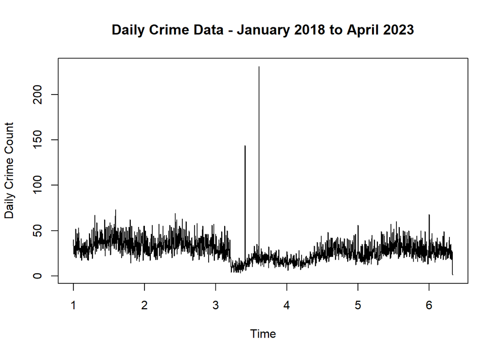

```r
# Plotting the daily and hourly crime
# Note that the weekly and daily plots will look the same since they are taken from the
# same data with only frequency calculated differently, so we won't bother plotting weekly
ts.plot(ts_crimes_daily, ylab='Daily Crime Count',
        main='Daily Crime Data - January 2018 to April 2023')
```

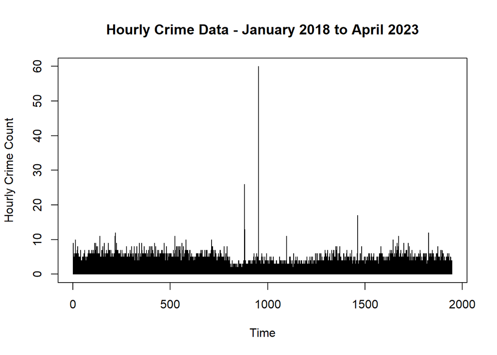

```r
ts.plot(ts_crimes_hourly, ylab='Hourly Crime Count',
        main='Hourly Crime Data - January 2018 to April 2023')
```

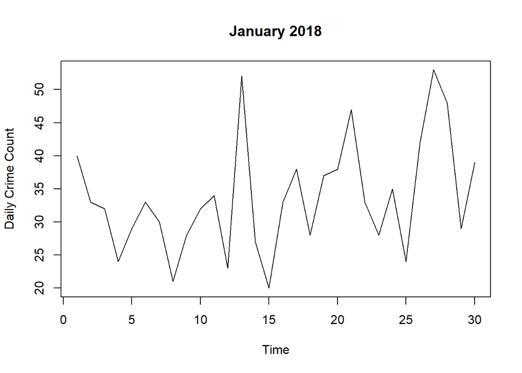

```r
# Plot 1 month of the daily TS
ts.plot(ts_crimes_daily[1:30], ylab='Daily Crime Count',
        main= 'January 2018')
```

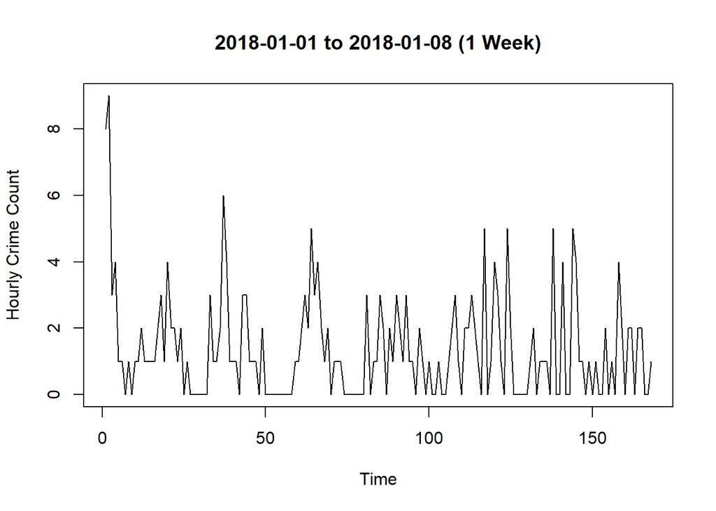

```r
# Plot 1 week of the daily TS
ts.plot(ts_crimes_hourly[1:168], ylab='Hourly Crime Count',
        main='2018-01-01 to 2018-01-08 (1 Week)')
```

From the TS plots of smaller windows we can see crime tends to spike on the weekends every 6-7 days or so. From the hourly data, there appear to be multiple spikes in a day, perhaps one in the middle of the day and one overnight.

```r
# Inspect what appear to be some outliers
crimes_daily_outliers <- filter(crimes_daily, count>100)
print(crimes_daily_outliers)
```

```
## # A tibble: 2 × 2
##   date_new   count
##   <date>     <dbl>
## 1 2020-05-31   144
## 2 2020-08-10   231
```

```r
crimes_hourly_outliers <- filter(crimes_hourly, count>20)
print(crimes_hourly_outliers)
```

```
##                  hour count
## 1 2020-05-30 20:00:00    26
## 2 2020-05-30 21:00:00    23
## 3 2020-08-10 00:00:00    60
## 4 2020-08-10 01:00:00    60
## 5 2020-08-10 02:00:00    39
## 6 2020-08-10 03:00:00    25
```

There are a couple of days in the 2020 data that are anomalies. These are days where there was widespread protest and activism taking place across Chicago. Given the circumstances of the Covid-19 pandemic this type of activity is unlikely to occur at random.

```r
# Check for stationarity of daily and hourly TS'
adf_daily <- adf.test(ts_crimes_daily)
print(adf_daily)
```

```
##
##  Augmented Dickey-Fuller Test
##
## data:  ts_crimes_daily
## Dickey-Fuller = -4.6533, Lag order = 12, p-value = 0.01
## alternative hypothesis: stationary
```

```r
adf_hourly <- adf.test(ts_crimes_hourly)
print(adf_hourly)
```

```
##
##  Augmented Dickey-Fuller Test
##
## data:  ts_crimes_hourly
## Dickey-Fuller = -26.435, Lag order = 36, p-value = 0.01
## alternative hypothesis: stationary
```

```r
# Check descriptive statistics
summary(ts_crimes_daily)
```

```
##    Min. 1st Qu.  Median    Mean 3rd Qu.    Max.
##    1.00   20.00   27.00   28.43   35.00  231.00
```

```r
summary(ts_crimes_hourly) # at least 25% of hours do not have a crime logged within them
```

```
##    Min. 1st Qu.  Median    Mean 3rd Qu.    Max.
##   0.000   0.000   1.000   1.186   2.000  60.000
```

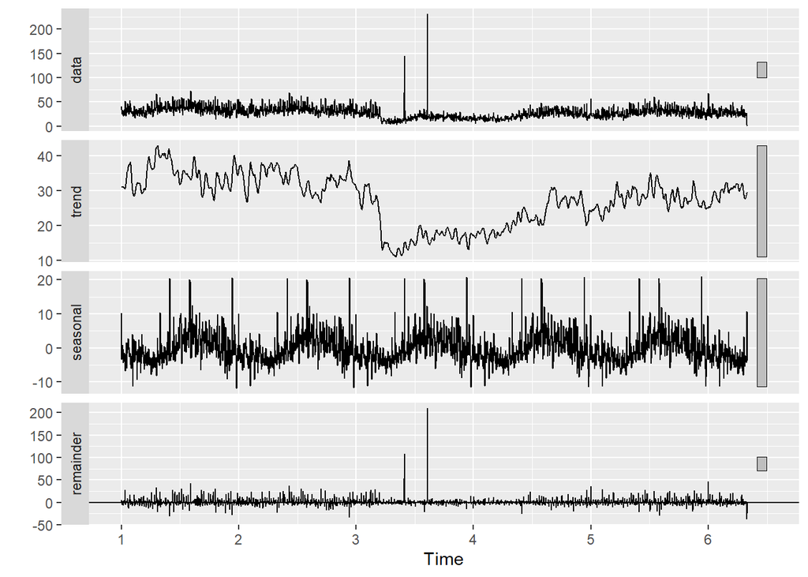

```r
# STL decompositions for all 3 TS'
ts_crimes_daily %>%
  stl(t.window=15, s.window=15, robust=TRUE) %>%autoplot()
```

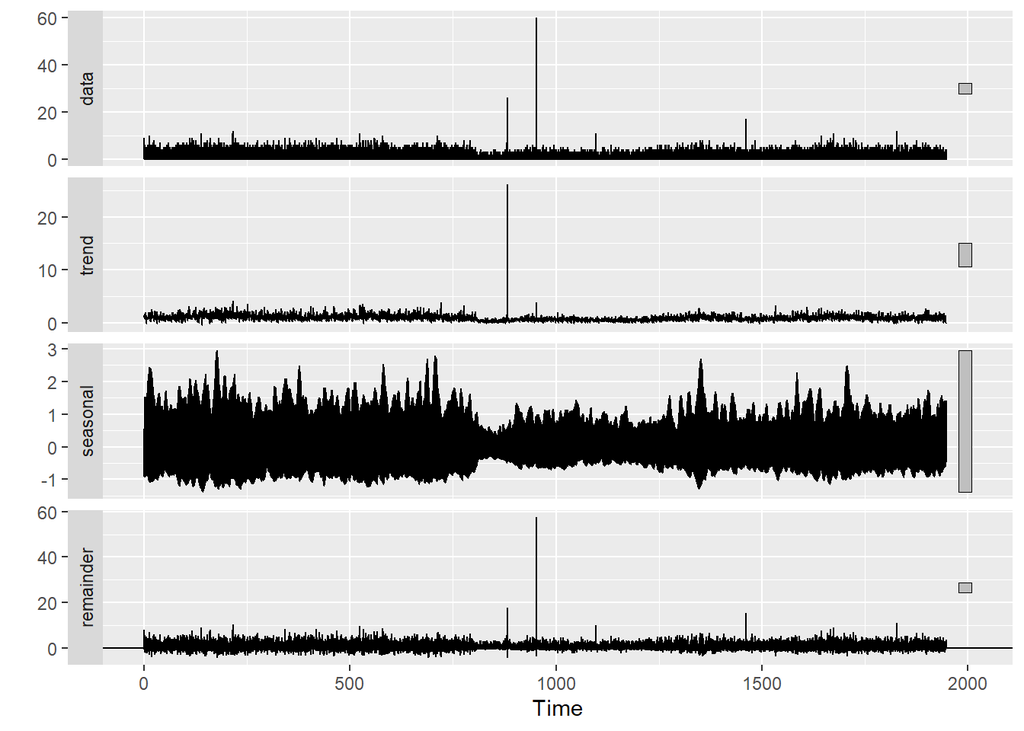

```r
ts_crimes_hourly %>%
  stl(t.window=15, s.window=15, robust=TRUE) %>% autoplot()
```

The trend and seasonality are both easier to pick out when looking at the daily data but less apparent in the hourly data, perhaps because we are dealing a with much smaller numbers of crimes in the hourly time-frame vs. the daily time-frame.

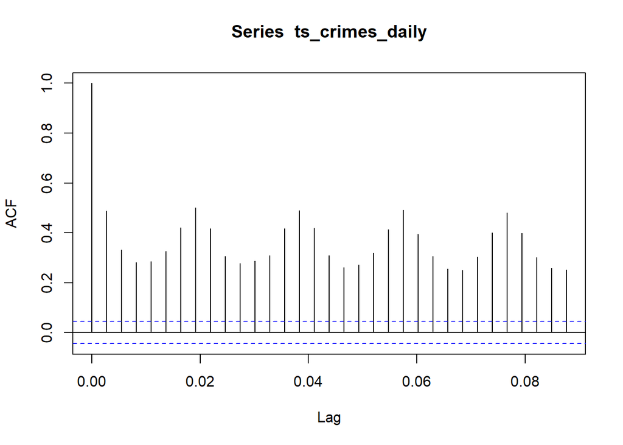

```r
# Check for autocorrelation
acf(ts_crimes_daily)
```

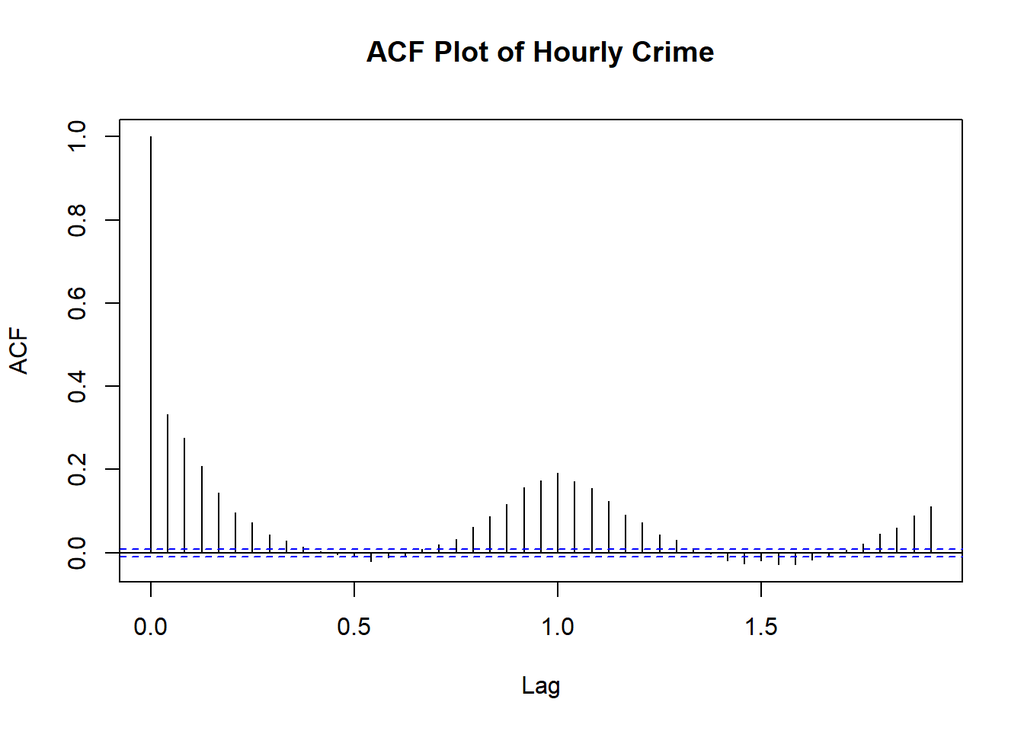

```r
acf(ts_crimes_hourly, main='ACF Plot of Hourly Crime')
```

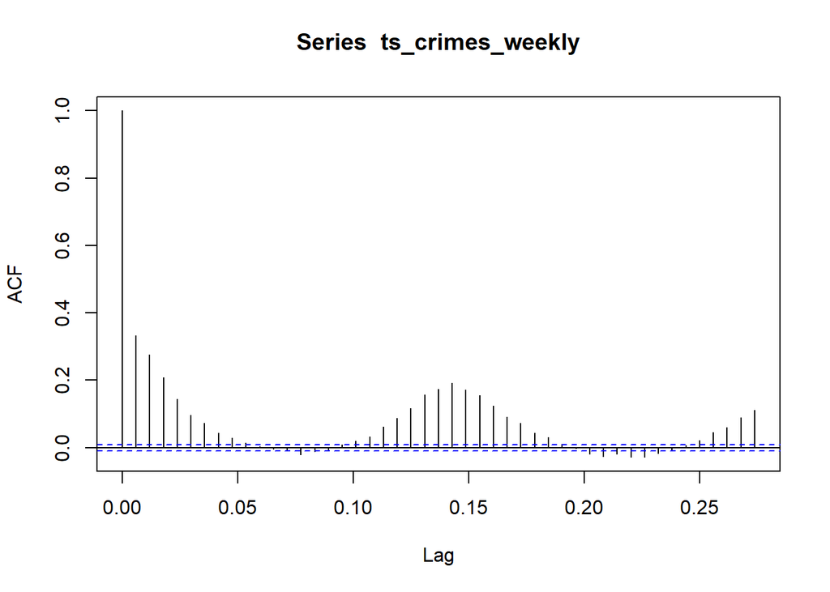

```r
acf(ts_crimes_weekly)
```

There are some spikes in the hourly ACF plot which indicates some seasonality at the hourly level, although this was difficult to see with the STL decomposition. Based on the EDA, daily and hourly crime in Chicago’s Near North Neighborhood both appear to have some seasonality (day of the week and hour of the day).

```r
# Create train/test splits
cd_train <- crimes_daily[1:1461,] # split on January 1st, 2022
cd_train_ts <- ts(cd_train$count, frequency = 365) # frequency repeats each year
cd_test <- crimes_daily[1462:1946,]
cd_test_ts <- ts(cd_test$count, frequency = 365) # frequency repeats each year

ch_train <- crimes_hourly[1:35064,] # split on January 1st, 2022
ch_train_ts_daily <- ts(ch_train$count, frequency = 24) # frequency repeats each day
ch_test <- crimes_hourly[35065:46704,]
ch_test_ts_daily <- ts(ch_test$count, frequency = 24) # frequency repeats each day

ch_train_ts_weekly <- ts(ch_train$count, frequency = 168) # frequency repeats each week
ch_test_ts_weekly <- ts(ch_test$count, frequency = 168)

ch_train_ts_yearly <- ts(ch_train$count, frequency = 8760) # frequency repeats each year
ch_test_ts_yearly <- ts(ch_test$count, frequency = 8760)

ch_train_ts <- ts(ch_train$count) # no frequency assigned for 1st model
ch_test_ts <- ts(ch_test$count)
```

3. MODEL FITTING AND FORECASTING

```r
# Fit some auto arima models on the hourly data
aa1 <- auto.arima(ch_train_ts, seasonal = TRUE)
print(aa1)
```

```
## Series: ch_train_ts
## ARIMA(0,1,1) with drift
##
## Coefficients:
##           ma1    drift
##       -0.7107  -0.0001
## s.e.   0.0056   0.0021
##
## sigma^2 = 1.89:  log likelihood = -60909.54
## AIC=121825.1   AICc=121825.1   BIC=121850.5
```

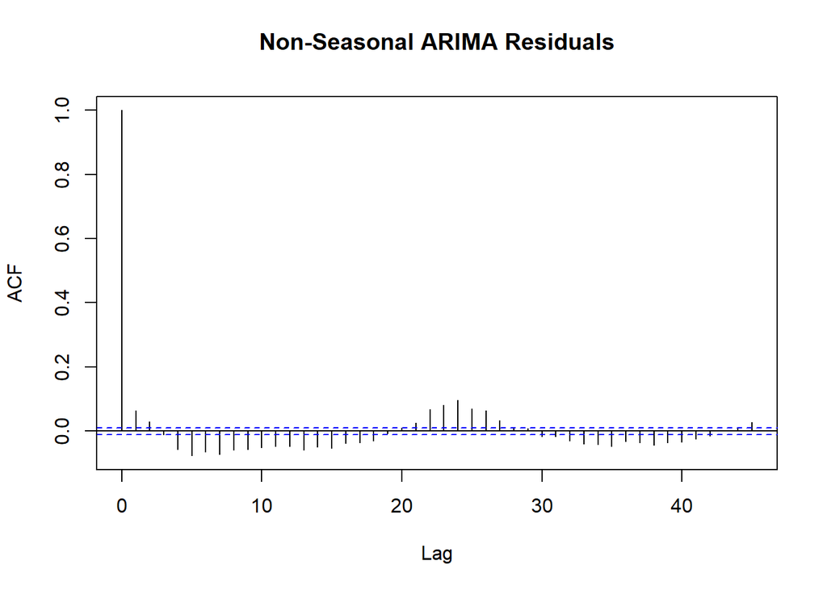

```r
acf(aa1$residuals, main='Non-Seasonal ARIMA Residuals')
```

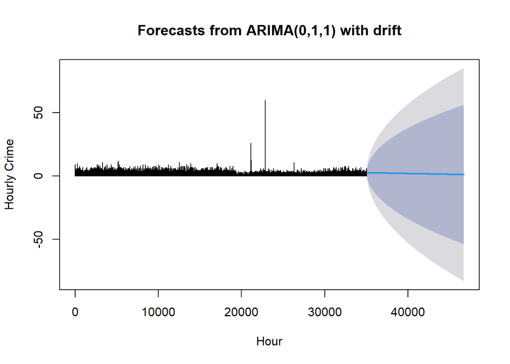

```r
# Forecast with the first non-seasonal model
forecast_a <- forecast(aa1, h=11640)
plot(forecast_a, xlab='Hour', ylab='Hourly Crime')
```

```r
#print(forecast_a, 10)
```

```r
# Day of the week Seasonal Arima (frequency = 168)
aa2 <- auto.arima(ch_train_ts_weekly)
print(aa2)
```

```
## Series: ch_train_ts_weekly
## ARIMA(5,1,0)
##
## Coefficients:
##           ar1      ar2      ar3      ar4      ar5
##       -0.6216  -0.3823  -0.2430  -0.1699  -0.1052
## s.e.   0.0053   0.0062   0.0064   0.0062   0.0053
##
## sigma^2 = 1.92:  log likelihood = -61187.5
## AIC=122387   AICc=122387   BIC=122437.8
```

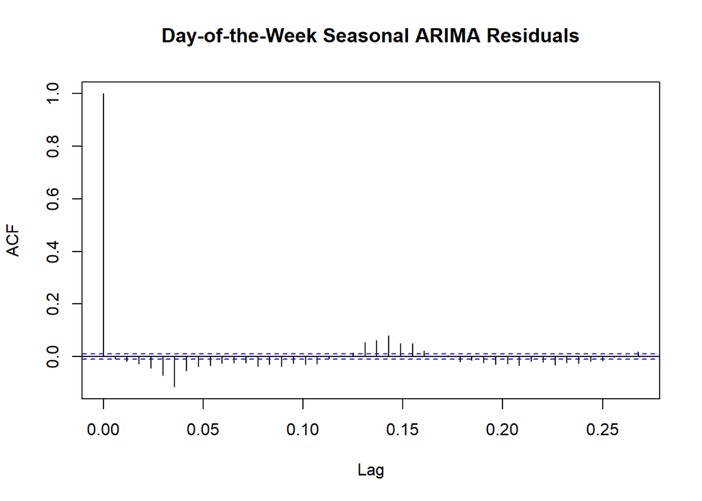

```r
acf(aa2$residuals, main='Day-of-the-Week Seasonal ARIMA Residuals')
```

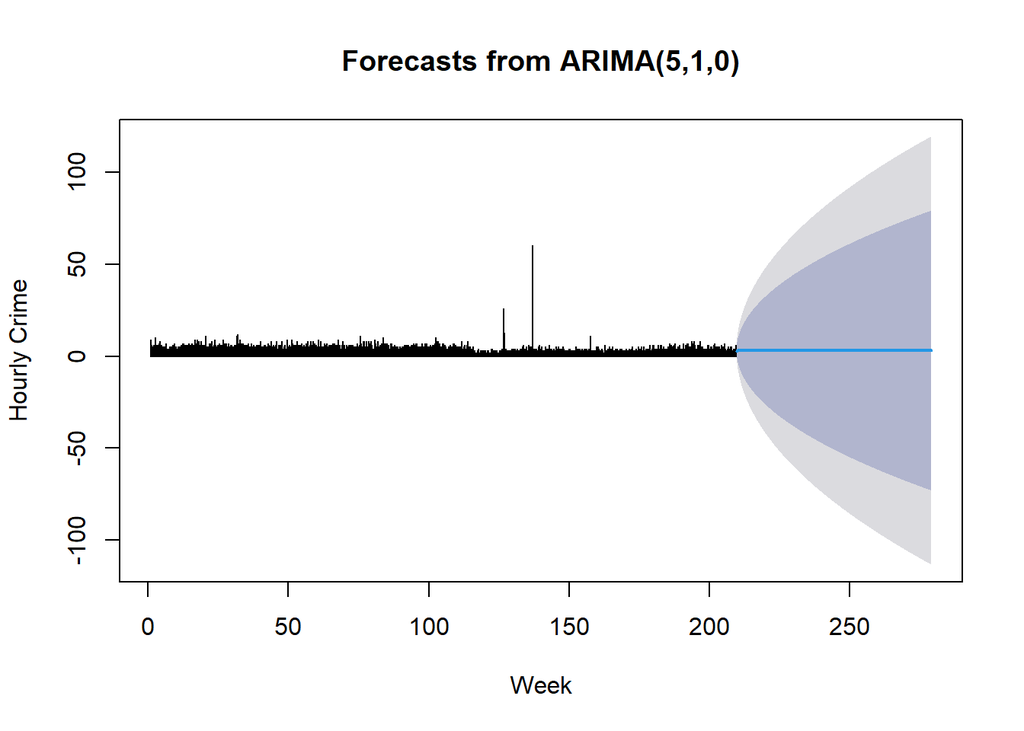

```r
# Forecast with 1st seasonal model
seasonal_forecast_a <- forecast(aa2, h=11640)
plot(seasonal_forecast_a, xlab='Week', ylab='Hourly Crime')
```

```r
#print(seasonal_forecast_a)
```

```r
# Hour of the day seasonality (frequency = 24)
aa3 <- auto.arima(ch_train_ts_daily)
print(aa3)
```

```
## Series: ch_train_ts_daily
## ARIMA(0,1,1)(0,0,2)[24] with drift
##
## Coefficients:
##           ma1    sma1    sma2    drift
##       -0.7455  0.0904  0.0662  -0.0001
## s.e.   0.0060  0.0055  0.0052   0.0021
##
## sigma^2 = 1.865:  log likelihood = -60678.84
## AIC=121367.7   AICc=121367.7   BIC=121410
```

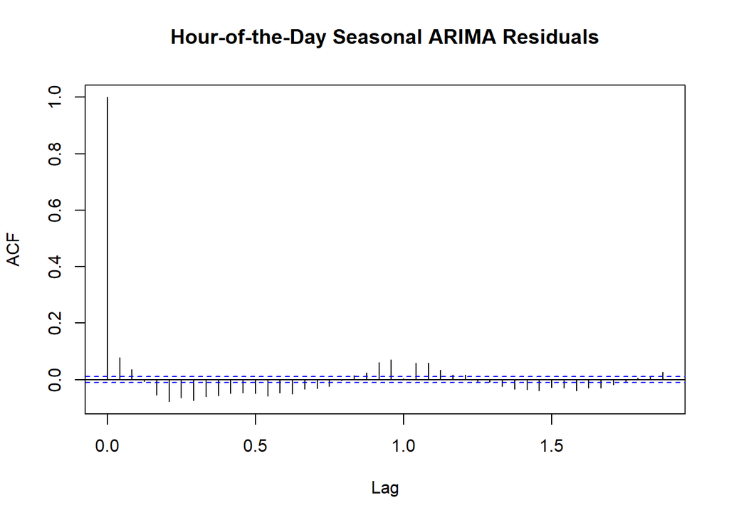

```r
acf(aa3$residuals, main='Hour-of-the-Day Seasonal ARIMA Residuals')
```

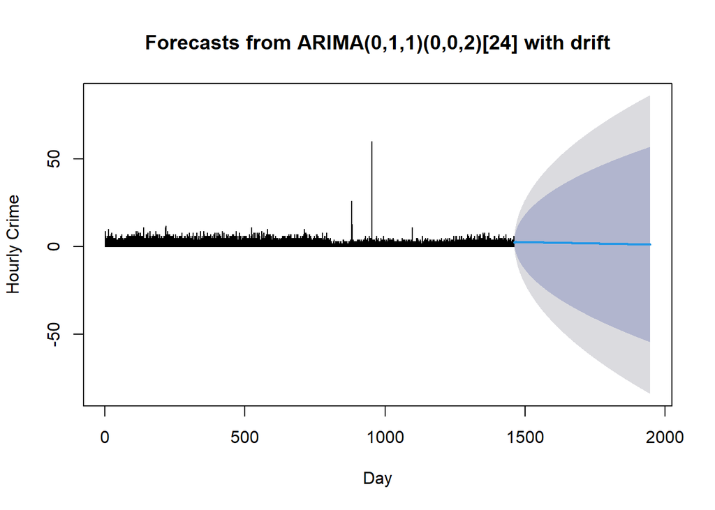

```r
# Forecast with 2nd seasonal model
seasonal_forecast_b <- forecast(aa3, h=11640)
plot(seasonal_forecast_b, xlab='Day', ylab='Hourly Crime')
```

```r
#print(seasonal_forecast_b)
```

```r
# Day of the year Seasonal Arima (frequency = 8765)
#aa4 <- auto.arima(ch_train_ts_yearly)
#print(aa4)
#acf(aa4$residuals)
```

```r
# Forecast with 3rd seasonal model
#seasonal_forecast_c <- forecast(aa4, h=11640)
#plot(seasonal_forecast_c, xlab='Year', ylab='Hourly Crime')
#print(seasonal_forecast_c)
```

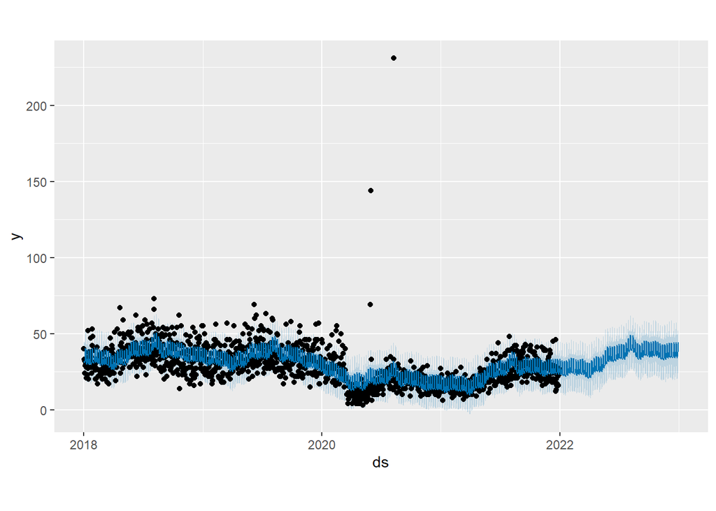

```r
# Process a train and test df for Prophet formatting (daily level)
cd_train2 <- cd_train
colnames(cd_train2) <- c('ds', 'y')

# Fit a Prophet model
d <- prophet(cd_train2, yearly.seasonality=TRUE, daily.seasonality=TRUE)

# Make a new df to store Prophet forecasts along with historical values
prophet_d_test <- make_future_dataframe(d, periods = 365)

# Forecast with Prophet model
prophet_d_forecast <- predict(d, prophet_d_test)

# Plot the Prophet forecast
plot(d, prophet_d_forecast)
```

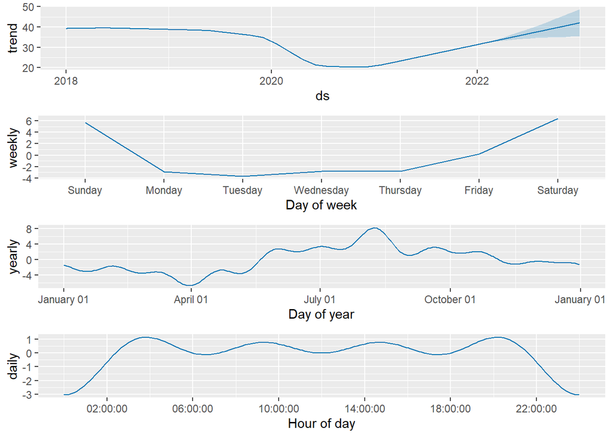

```r
# Plotting forecast components
prophet_plot_components(d, prophet_d_forecast)
```

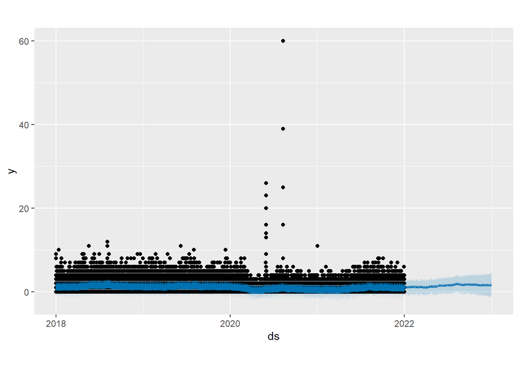

```r
# Process a train and test df for Prophet formatting (hourly level)
ch_train2 <- ch_train
colnames(ch_train2) <- c('ds', 'y')

# Fit a Prophet model
h <- prophet(ch_train2, yearly.seasonality=TRUE)

# Make a new df to store Prophet forecasts along with historical values
prophet_h_test <- make_future_dataframe(h, periods = 365)

# Forecast with Prophet model
prophet_h_forecast <- predict(h, prophet_h_test, freq = 'hour')

# Plot the Prophet forecast
plot(h, prophet_h_forecast)
```

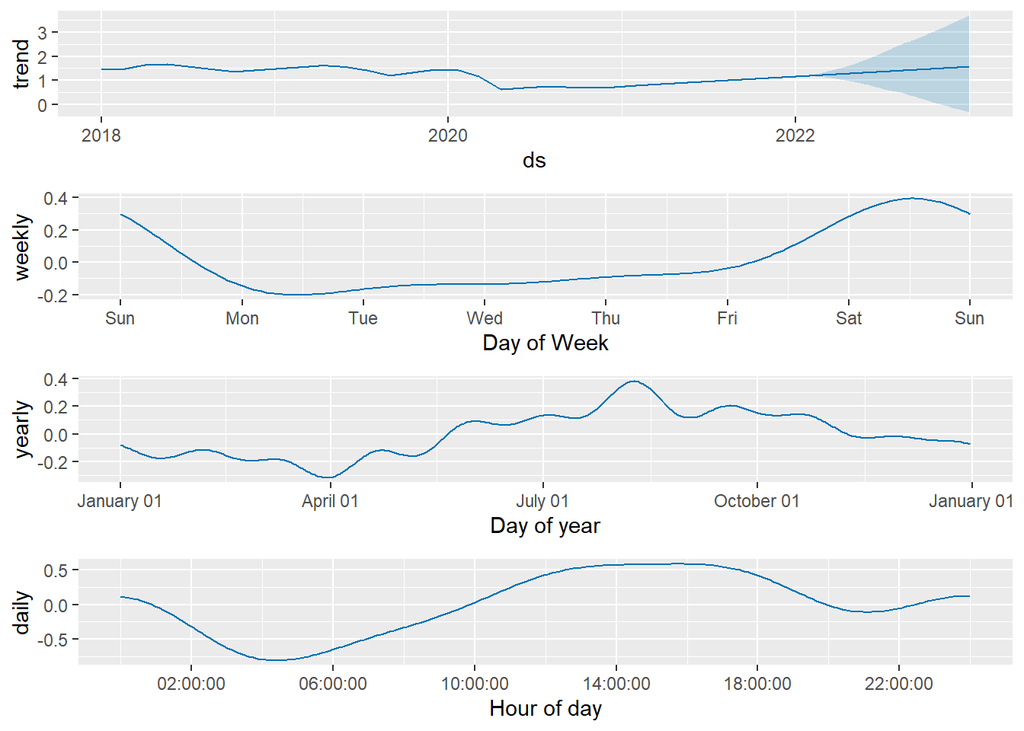

```r
# Plotting forecast components
prophet_plot_components(h, prophet_h_forecast)
```

4. RESULTS ANAYLSIS

```r
# Take the point forecast for the hourly Prophet predictions
prophet_h_forecast_points <- prophet_h_forecast$yhat[1:11640]
```

```r
# Calculate accuracy metrics for the forecasts
rmse1 <- sqrt(mean((forecast_a$mean - ch_test$count)^2))
smape1 <-mean(2 * abs(
  ch_test$count - forecast_a$mean) / (abs(ch_test$count) + abs(forecast_a$mean))) * 100
mae1 <- mae(ch_test$count, forecast_a$mean)

rmse2 <- sqrt(mean((seasonal_forecast_a$mean - ch_test$count)^2))
smape2 <-mean(2 * abs(
  ch_test$count - seasonal_forecast_a$mean) /
    (abs(ch_test$count) + abs(seasonal_forecast_a$mean))) * 100
mae2 <- mae(ch_test$count, seasonal_forecast_a$mean)


rmse3 <- sqrt(mean((seasonal_forecast_b$mean - ch_test$count)^2))
smape3 <-mean(2 * abs(
  ch_test$count - seasonal_forecast_b$mean) /
    (abs(ch_test$count) + abs(seasonal_forecast_b$mean))) * 100
mae3 <- mae(ch_test$count, seasonal_forecast_b$mean)

rmse4 <- sqrt(mean((prophet_h_forecast_points - ch_test$count)^2))
smape4 <-mean(2 * abs(
  ch_test$count - prophet_h_forecast_points) /
    (abs(ch_test$count) + abs(prophet_h_forecast_points))) * 100
mae4 <- mae(ch_test$count, prophet_h_forecast_points)

# Store the calculated metrics in vectors
rmse_results <- c(rmse1, rmse2, rmse3, rmse4)
mae_results <- c(mae1, mae2, mae3, mae4)
smape_results <- c(smape1, smape2, smape3, smape4)

# Create an empty dataframe
results <- data.frame(matrix(ncol = 4, nrow = 4))

# Assign column names
colnames(results) <- c('Model', 'MAE', 'RMSE', 'sMAPE')

# Fill in data column-by-column
results$Model <- c('Non-Seasonal Arima', 'Day-of-the-Week Seasonal Arima',
                   'Hour-of-the-Day Seasonal Arima',
                   'Prophet')
results$MAE <- mae_results
results$RMSE <- rmse_results
results$sMAPE <- smape_results

# View
results
```

```
##                            Model      MAE     RMSE    sMAPE
## 1             Non-Seasonal Arima 1.298829 1.547270 103.2134
## 2 Day-of-the-Week Seasonal Arima 1.981880 2.208349 113.2407
## 3 Hour-of-the-Day Seasonal Arima 1.311826 1.560554 103.3981
## 4                        Prophet 1.013137 1.287885 101.4600
```